# Homework 3: Coding Practice

Jamie Ash

due: 2021-09-15

# 1 Summary statistics and Data Visualization

**Statistics:** Let’s look at some basic summary statistics. In total there are 209 fish species encountered and counted in these surveys. Identify the top twelve species in terms of these three statistics: (1) mean abundance, (2) maximum abundance, (3) coefficient of variation in abundance. In other words, which species are most abundant on average, which reach the highest abundances, and which have the most variable abundances? To make these calculations, you’ll want to focus on the ‘count’ column (number of fish observed at a location), as well as the ‘commonname’ or ‘taxonname’ columns. The latter two are nearly identical, you can choose which you prefer to use. To do these calculations in base R, tapply() or aggregate() will be useful, or to use the ‘tidyverse’ you can look into the summarize() function in the package dplyr.

**Visualization:** Now let’s visualize how the abundances of the most common species vary with depth, to get a sense for whether species have different depth niches. Using the top twelve species based on mean abundance, plot a scatter-plot of count vs. depth (the column is named ‘depth’). Add a smoother to help visualize mean count vs. depth, put all twelve species on a single plot (with twelve panels), and make sure each panel is titled using the species name. The patterns in abundance will be easier to see if you transform the counts, for example by taking the square root of the counts, because the counts are very skewed. I would like you to make this twelve-paneled figure in two ways. First, write a ‘for’ loop in which you iterate your plotting code for the twelve species. The function scatter.smooth() is a simple one for making a scatterplot with a smoother. Second, use ggplot() to do the same thing. The functions geom_point(), geom_smooth(), and facet_wrap() will be helpful.

```r
infile <- "..\\data\\"
fish   <- read.csv(paste(infile, "CRCP_Reef_Fish_Surveys_Hawaii_expanded.csv", sep = ""))

uabun <- aggregate(count ~ commonname, FUN = mean, data = fish)
mabun <- aggregate(count ~ commonname, FUN = max,  data = fish)
vabun <- aggregate(count ~ commonname, FUN = sd,  data = fish)
vabun$count <- vabun$count/mabun$count # CoV = sd/u

ind   <- sort(uabun[,2], decreasing = TRUE, index.return = TRUE)$ix
uabun <- uabun[ind, ]
ind   <- sort(mabun[,2], decreasing = TRUE, index.return = TRUE)$ix
mabun <- mabun[ind, ]
ind   <- sort(vabun[,2], decreasing = TRUE, index.return = TRUE)$ix
vabun <- vabun[ind, ]
```

## 1.1 Summary statistics

### 1.1.1 Mean Abundance: Top 20

```r
df <- data.frame(uabun[1:20,])
colnames(df) <- c("Fish Name", "Mean Abundance")
rownames(df) <- c(as.character(1:20))
df
```

```
##                    Fish Name Mean Abundance
## 1       Vanderbilt's chromis      30.403158
## 2              Agile chromis      18.994337
## 3          Brown surgeonfish       6.220833
## 4        Spotted surgeonfish       6.114540
## 5                Yellow tang       5.026948
## 6  Common bluestripe snapper       4.865693
## 7           Arc-eye hawkfish       2.948040
## 8   Hawaiian bicolor chromis       2.560062
## 9       Whitebar surgeonfish       2.466069
## 10             Saddle wrasse       2.324507
## 11             Mackerel scad       1.840067
## 12           Striated wrasse       1.838889
## 13     Pebbled butterflyfish       1.719706
## 14         Black triggerfish       1.644315
## 15    Johnston Island damsel       1.461194
## 16           Pacific gregory       1.281583
## 17    Orangespot surgeonfish       1.212912
## 18         Ornamented wrasse       1.154223
## 19         Four-lined wrasse       1.107937
## 20          Manybar goatfish       1.106173
```

### 1.1.2 Maximum Abundance: Top 20

```r
df <- data.frame(mabun[1:20,])
colnames(df) <- c("Fish Name", "Max Abundance")
rownames(df) <- c(as.character(1:20))
df
```

```
##                    Fish Name Max Abundance
## 1  Common bluestripe snapper           600
## 2              Agile chromis           500
## 3       Vanderbilt's chromis           500
## 4   Hawaiian bicolor chromis           200
## 5     Delicate round herring           150
## 6           Hawaiian chromis           150
## 7              Mackerel scad           150
## 8            Striated wrasse           100
## 9          Threespot chromis           100
## 10        Yellowfin goatfish            90
## 11   Iridescent cardinalfish            86
## 12         Whitetail chromis            80
## 13          Arc-eye hawkfish            72
## 14         Brown surgeonfish            60
## 15       Spotted surgeonfish            60
## 16   Shoulderbar soldierfish            54
## 17               Yellow tang            52
## 18         Four-lined wrasse            50
## 19     Indo-Pacific sergeant            40
## 20    Sunburst butterflyfish            40
```

```r
df <- data.frame(vabun[1:20,])
colnames(df) <- c("Fish Name", "Coefficient of Variation")
rownames(df) <- c(as.character(1:20))
df
```

```
##                     Fish Name Coefficient of Variation
## 1               Green jobfish                0.3104906
## 2                Peacock hind                0.2620394
## 3      Longnose butterflyfish                0.2471504
## 4          Blackside hawkfish                0.2468229
## 5                Moorish idol                0.2134802
## 6          Yellow-edged moray                0.2117299
## 7         Chinese trumpetfish                0.2030620
## 8            Hawaiian Hogfish                0.2016744
## 9       Spectacled parrotfish                0.1959663
## 10           Blacktail wrasse                0.1958031
## 11       Ornate butterflyfish                0.1942589
## 12 Hawaiian whitespotted toby                0.1773380
## 13               Pearl wrasse                0.1767798
## 14    Longnose butterfly fish                0.1695395
## 15       Whitespotted boxfish                0.1649758
## 16         Lizardfish species                0.1646175
## 17     Teardrop butterflyfish                0.1591822
## 18      Whitespotted filefish                0.1580444
## 19        Goldsaddle goatfish                0.1571139
## 20           Banded angelfish                0.1560856
```

## 1.2 Visualization

### 1.2.1 Using ggplot2: Top 12

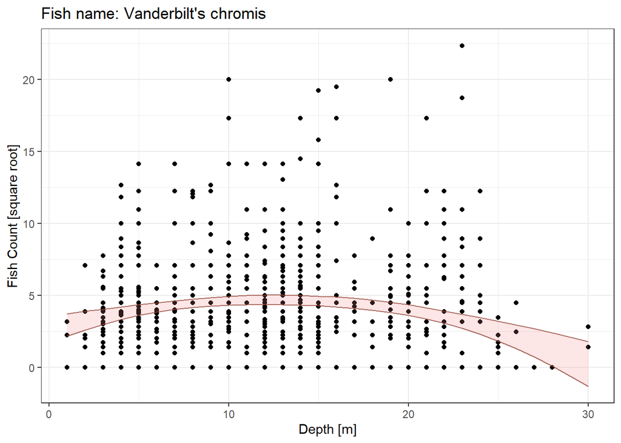

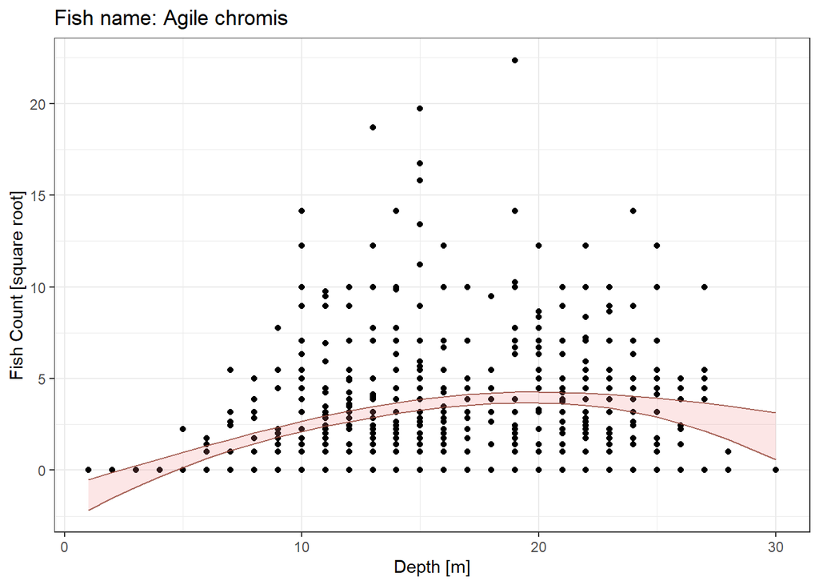

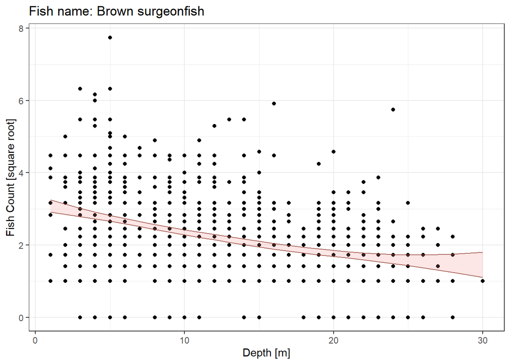

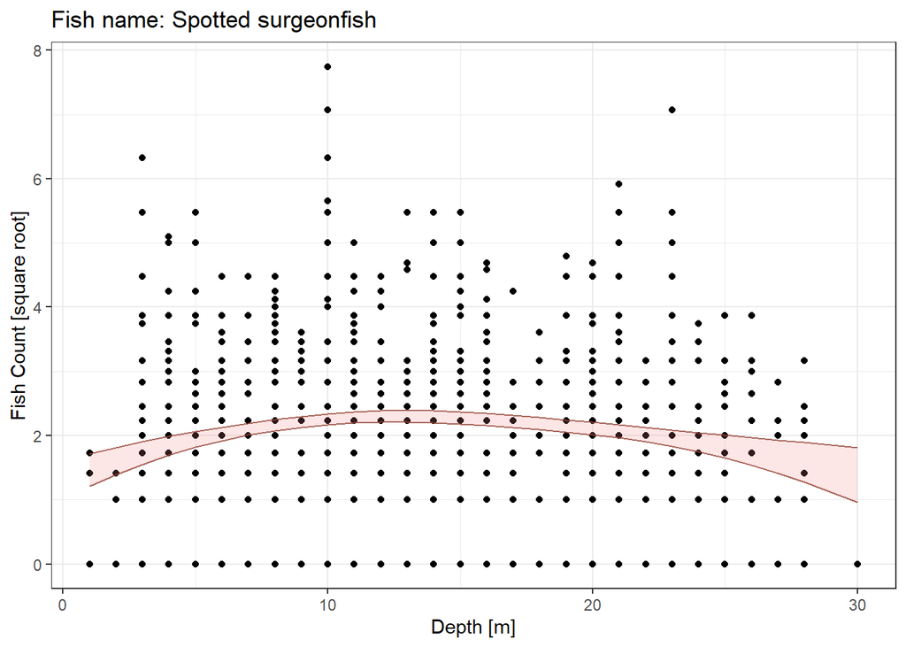

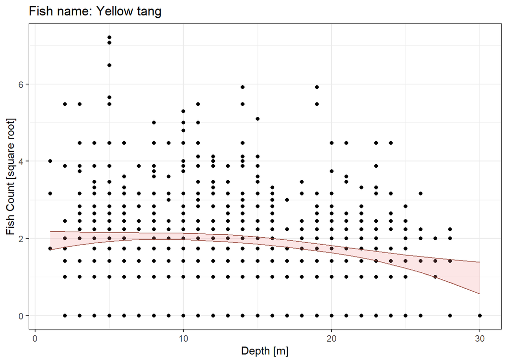

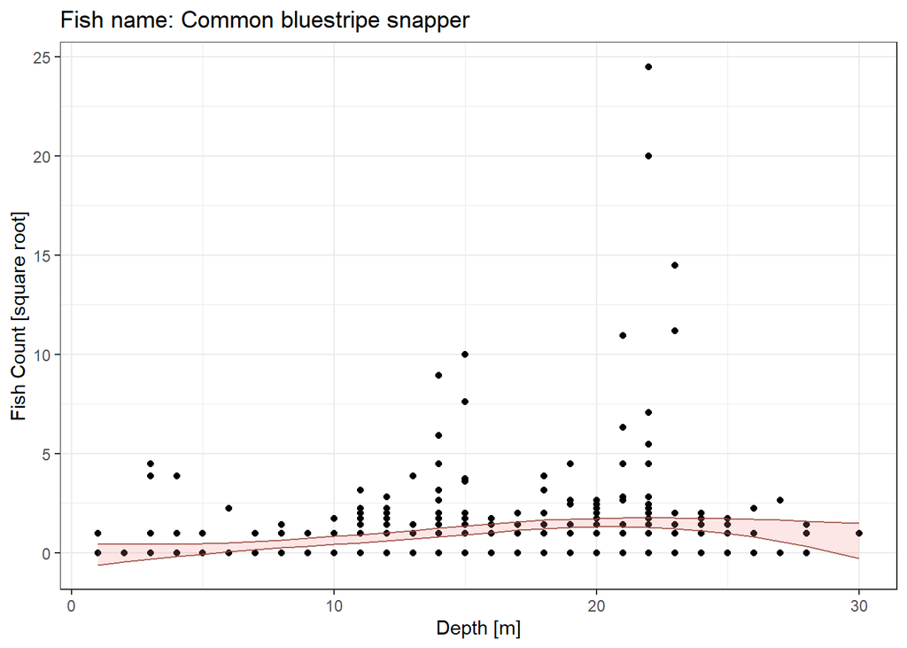

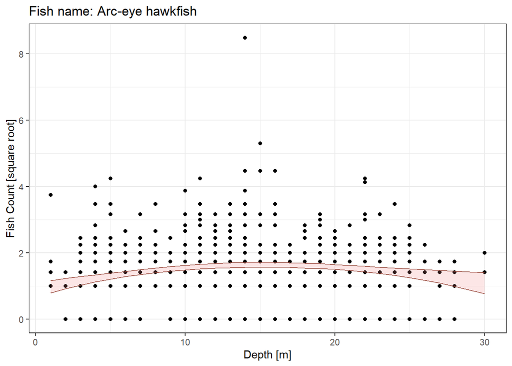

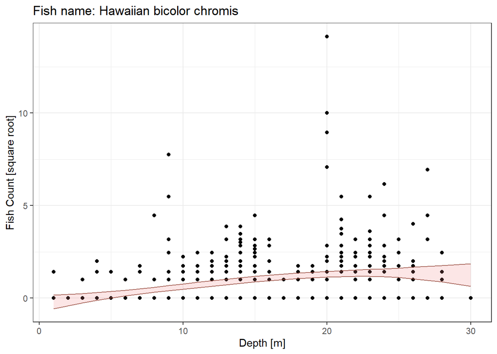

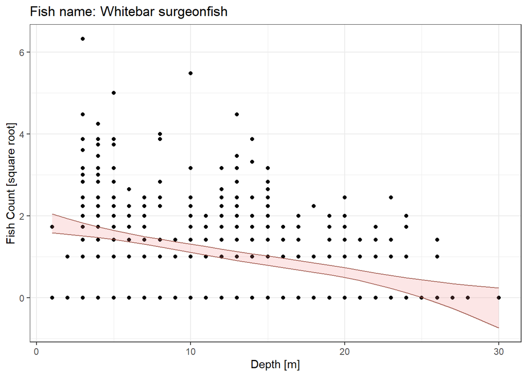

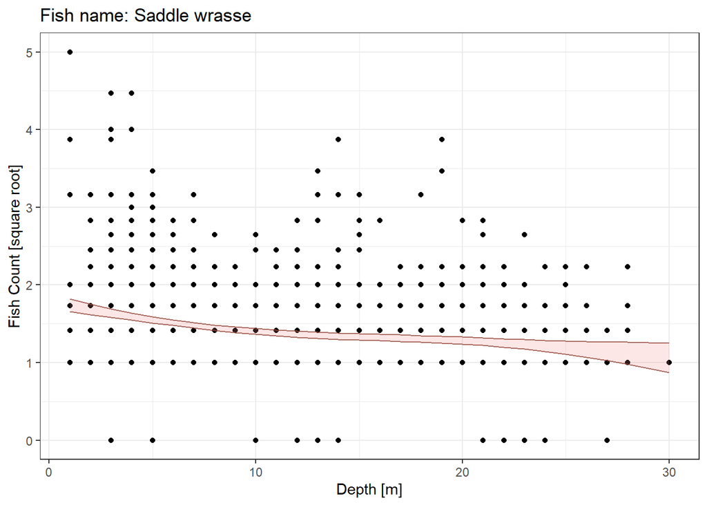

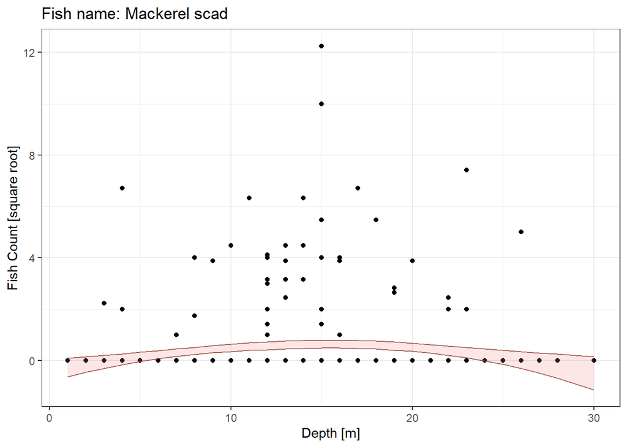

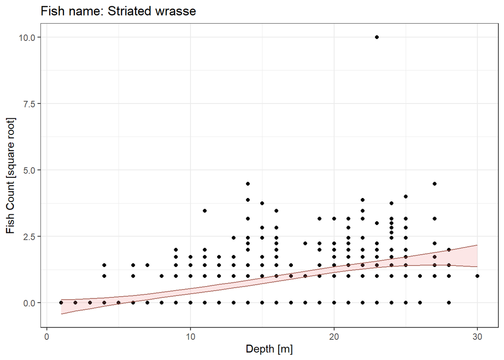

```r
fish$count <- as.numeric(fish$count)
fish$depth <- as.numeric(fish$depth)

nam <- uabun[1:12,]$commonname
#par(mfrow = c(round(length(nam)/3), 3))
for(i in nam) {
  idx   <- fish$commonname == i

  cnt   <- sqrt(fish[idx,]$count)
  dth   <- fish[idx,]$depth

  model1 <- loess(cnt ~ dth, normalize = FALSE, method = "loess", span = 1)
  pred   <- predict(model1, fish[idx,], se = TRUE, inf.rm = TRUE)
  pred$lwr <- pred$fit - 1.96*pred$se.fit
  pred$upr <- pred$fit + 1.96*pred$se.fit

  p <- ggplot() +
    geom_point(aes(dth, cnt))+
    xlab("Depth [m]") +
    ylab("Fish Count [square root]") +
    labs(title = paste("Fish name:", i)) +
    geom_line(aes(x = dth, y = pred$lwr),
              linetype = 1,
              alpha = 0.8,
              col = "coral4") +
    geom_line(aes(x = dth, y = pred$upr),
              linetype = 1,
              alpha = 0.8,
              col = "coral4") +
    geom_ribbon(aes(x = dth, ymin = pred$lwr, ymax = pred$upr),
                fill = "lightcoral",
                alpha = 0.2) +
    theme_bw()
    #+ theme(plot.background = element_rect(colour = "black"))

  print(p)
  }
```

### 1.2.2 Using scatter.smooth: Top 12

```r
nam <- uabun[1:12,]$commonname
#par(mfrow = c(round(length(nam)/3), 3))
for(i in nam) {
  idx <- fish$commonname == i
  y   <- sqrt(fish[idx,]$count)
  x   <- fish[idx,]$depth
  scatter.smooth(x, y,
                 xlab = "Depth [m]",
                 ylab = "Fish Count [square root]",
                 main = paste("Fish name:", i),
                 span = 1)
}
```

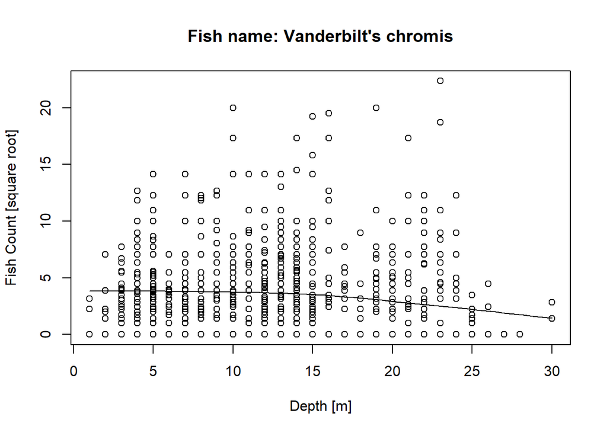

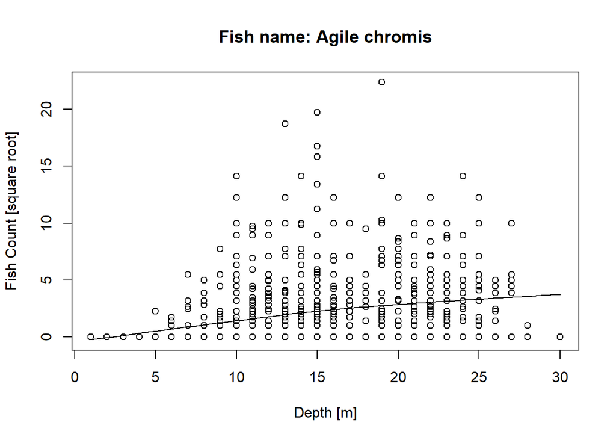

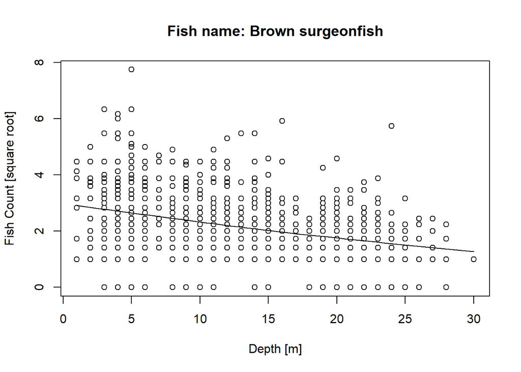

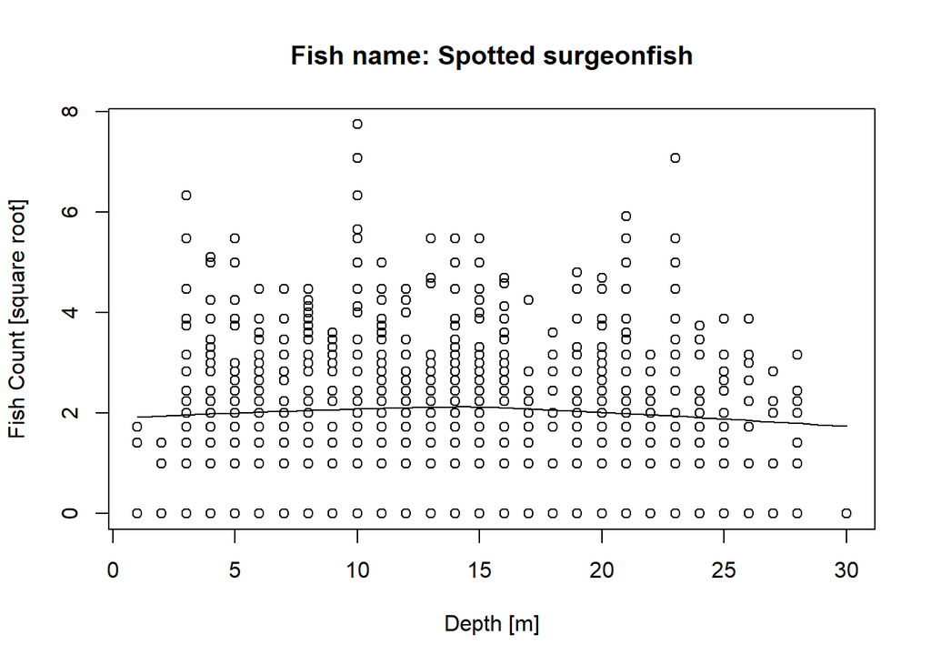

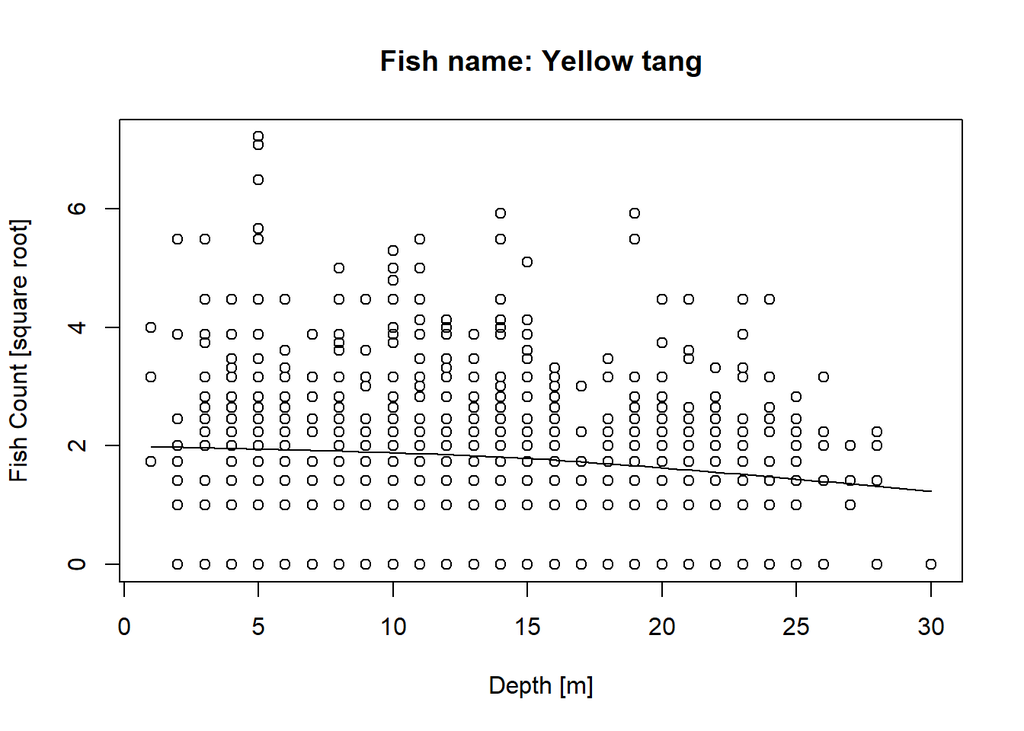

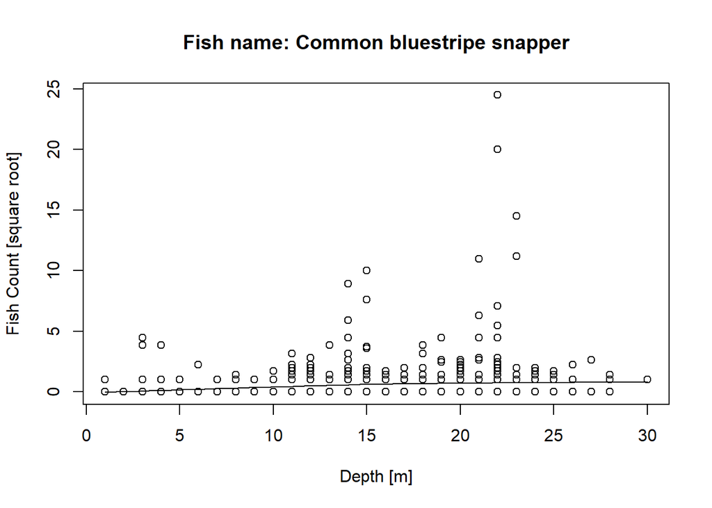

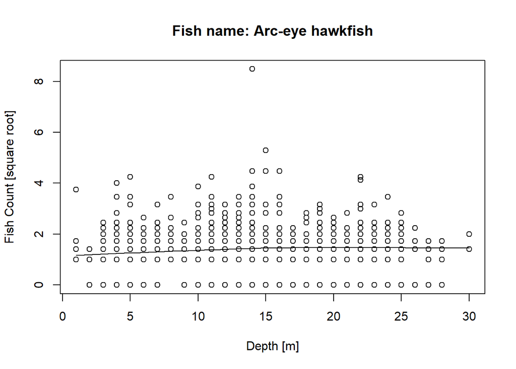

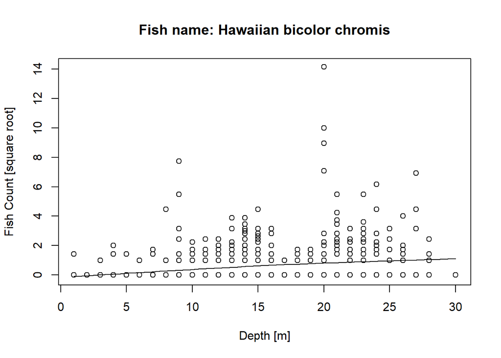

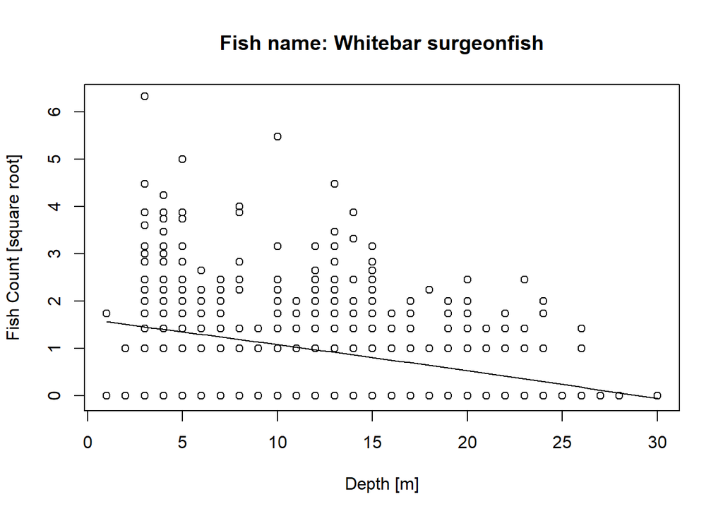

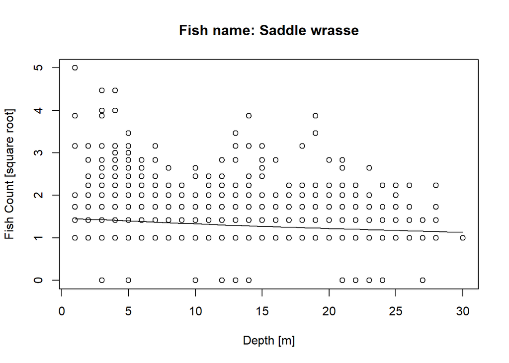

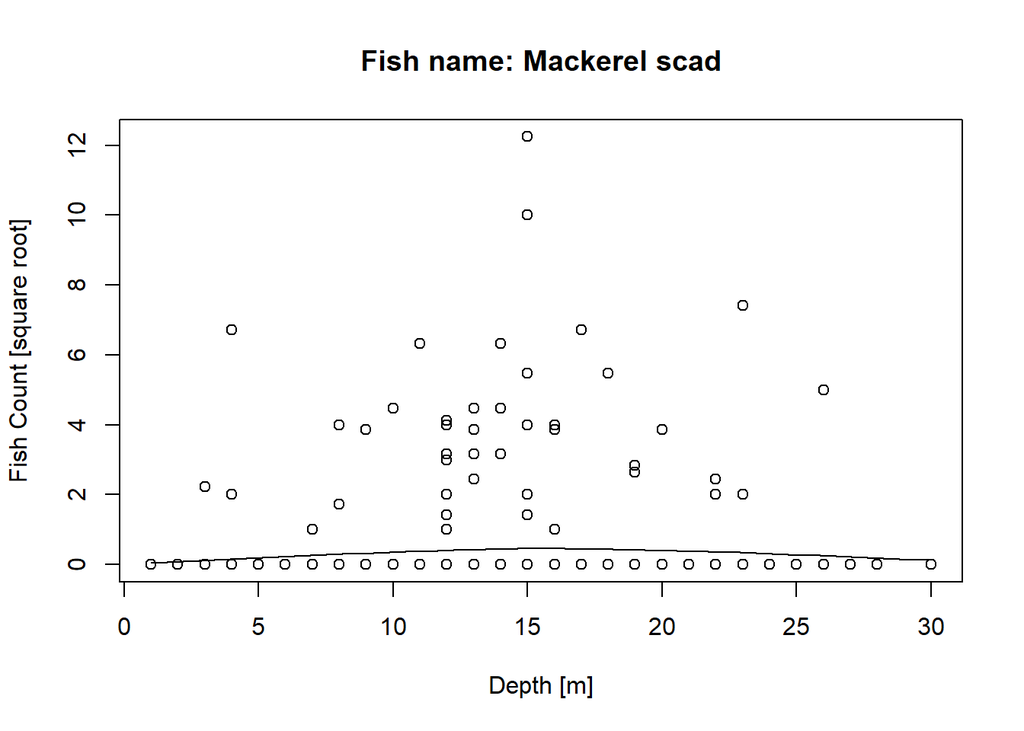

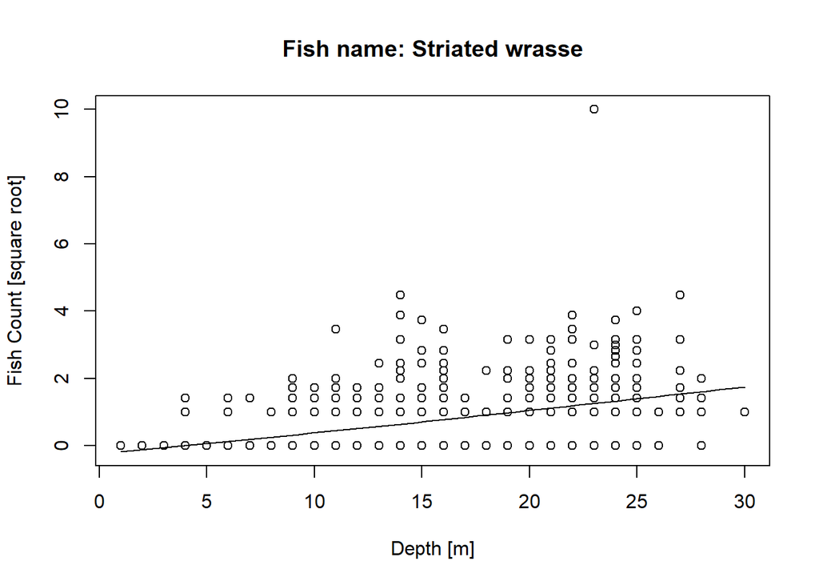

# 2 Conclusions

Finally, what are your conclusions from this visual inspection of the data?

**ANSWER:**

[output not shown]